# Field Trip and Perceptual Map

## Competitive Landscape

The CPP Farm Store operates in a relatively sheltered competitive environment within its immediate geographic radius. According to the store manager, a nearby **Stater Bros.** location — which previously represented a direct grocery competitor — has permanently closed, effectively reducing head-to-head competition in the surrounding area.

The manager identified **Trader Joe’s** as the store’s primary perceived competitor. This is a meaningful comparison: both stores cultivate a distinct, curated identity rather than competing on breadth of assortment. Trader Joe’s attracts a loyal customer base through unique private-label products, affordable pricing, and a community-oriented atmosphere — qualities the Farm Store shares in spirit, though through a very different lens rooted in agriculture and campus identity.

## Product Assortment Strategy

### Product Categories

The Farm Store carries a focused assortment centered on fresh, locally grown, and campus-produced items. Observed product categories during our visit include:

- **Fresh produce** — grown on CPP’s agricultural land (apples, oranges, blueberries, and other seasonal fruit observed during the visit)
- **Ready-to-eat items** — pre-made sandwiches and salads (e.g., Turkey Pesto Ciabatta, Italian Godfather, Croissant Sandwich)
- **Beverages** — fresh-squeezed juice, energy drinks, kombuchas, and canned beverages
- **Dairy & refrigerated snacks** — yogurt parfaits, fruit cups
- **Specialty / artisan items** — honey, wine, jams, plants, locally-made knick knacks

**Note**

**Manager highlight:** Fresh-squeezed **orange juice** was identified as the store’s most popular and recognizable product — a signature item with strong customer loyalty.

### Width of Product Lines

The store’s product width is **narrow** relative to conventional grocery competitors. Rather than stocking multiple brands across dozens of categories, the Farm Store concentrates on a curated, farm-direct selection consistent with a specialty or niche retail model.

### Depth of Product Lines

Within individual categories, depth is also **limited**. The selection reflects what is seasonally available from campus agricultural operations rather than a standardized year-round assortment. This is a feature of the farm-to-shelf model rather than a limitation — seasonal availability reinforces authenticity.

### Unique / Farm Store Brands

The Farm Store’s most distinctive differentiator is the **CPP-origin provenance** of its products. Items grown, raised, or produced on campus carry an authenticity that no competitor can replicate. The fresh-squeezed orange juice is the flagship example — a Farm Store original with demonstrated brand recognition and repeat-purchase loyalty.

### Comparison with Competitor (Trader Joe’s)

The Farm Store and Trader Joe’s share a commitment to curated, distinctive products rather than mass-market breadth. However, they diverge significantly across key assortment dimensions:

Product Assortment Comparison

| Dimension | CPP Farm Store | Trader Joe’s |
| --- | --- | --- |
| Product origin | Campus-grown, hyper-local | Private label, global sourcing |
| Assortment width | Very narrow | Moderate |
| Assortment depth | Shallow, seasonal | Deep, consistent year-round |
| Brand uniqueness | One-of-a-kind campus products | Exclusive TJ’s private label |
| Unique flagship | Fresh-squeezed orange juice | Multiple rotating private-label items |

## Pricing Strategy

From visible price tags observed during the visit, sample Farm Store prices include:

- Fuji Apples — **$2.49/lb**
- Blueberries — **$3.99**
- Fruit Cups — **$5.49**
- Yogurt Parfait — **$6.54**
- Turkey Pesto Ciabatta sandwich — **~$6.49**
- Italian Godfather sandwich — **$6.99**

Based on the store’s mission as a campus-affiliated educational retail operation, pricing appears **competitive with or slightly below** Trader Joe’s for comparable fresh produce items. For specialty items like fresh-squeezed OJ, pricing may reflect the artisanal, small-batch nature of production.

## Service

The Farm Store offers a **personalized, community-oriented service experience** consistent with its campus identity. Interactions appear informal and relationship-based rather than transactional. The manager’s direct engagement — including her awareness of which products resonate most with customers — suggests a store culture built on familiarity and local pride.

### Comparison with Trader Joe’s

Trader Joe’s is well-known for friendly, high-energy customer service enforced as a brand standard across all locations. The Farm Store’s service is similarly warm but more intimate in scale — closer to a farmers’ market interaction than a retail chain encounter. Customers who value personal connection over efficiency may actively prefer the Farm Store experience.

## Store Atmosphere

### Overall Impression

The store projects a **family-friendly, farm-to-table aesthetic** rooted in its agricultural identity. The atmosphere is casual, approachable, and distinctly non-commercial. The exterior features a **classic red barn design** with the “Cal Poly Pomona Farm Store” sign prominently displayed, flanked by greenery and a welcoming entrance — immediately communicating the farm identity before a customer steps inside.

### Observed Atmospheric Elements

Store Atmospheric Observations

| Element | Observation |
| --- | --- |
| Exterior design | Red barn facade, natural landscaping, open gate entrance with welcome signage |
| Interior décor | signage is farm themed, with wooden/farm country them displays |
| Lighting | fluorecent and warm, with a sun roof |
| Music | Family Friendly, upbeat |
| Layout & organization | Manager acknowledged **inventory organization is a current challenge**; the store is actively working to improve its setup to better serve the community |
| Staffing level | handful visible staff, light friendly engagement |

### Comparison with Trader Joe’s

Trader Joe’s invests heavily in atmospheric consistency — themed décor, upbeat music, and well-organized shelving are brand standards enforced chain-wide. The Farm Store’s atmosphere is more organic and less polished, which can read as either **charmingly authentic** or **operationally underdeveloped** depending on the customer’s expectations. Closing the inventory and organization gap — as the manager explicitly acknowledged as a priority — could significantly enhance the in-store experience without sacrificing the store’s genuine farm identity.

## Jobs to Be Done

Based on the manager’s input and the store’s positioning, the major motivations driving customer visits fall into three categories:

### Functional

- Purchase **fresh, locally grown produce** not easily available at conventional grocery stores
- Buy the Farm Store’s **signature fresh-squeezed orange juice** — a specific, loyalty-driving product that brings customers back
- Access **farm-direct food** with shorter supply chains and greater transparency about origin

### Emotional

- Feel **connected to the CPP campus community** and its agricultural mission
- Support **student learning and university programs** through everyday purchases
- Experience the satisfaction of **buying locally and sustainably**

### Social

- Share the Farm Store with **family** — the family-friendly atmosphere actively invites multi-generational visits
- Introduce **friends or neighbors** to the campus’s unique food offerings
- Participate in a **community-rooted retail experience** that feels meaningfully different from chain grocery shopping

### Comparison with Trader Joe’s

Trader Joe’s customers are primarily motivated by **value, product discovery, and convenience**. The Farm Store serves a more specific, values-driven motivation set — customers come with intention. This is a strength if the store consistently delivers on its signature products; it is a vulnerability if stock is unpredictable or the shopping experience is frustrating due to layout challenges.

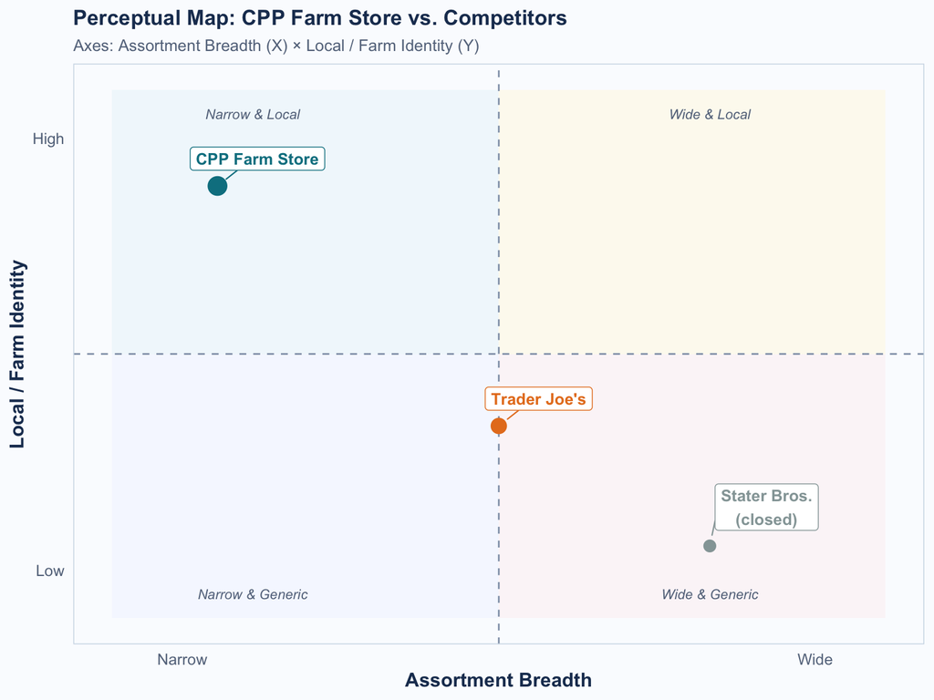

Figure 1: Perceptual Map — CPP Farm Store vs. Competitors

## Key Recommendations

The Farm Store’s most pressing opportunity is to **close the gap between its authentic identity and its operational execution**. The product positioning and community story are genuinely differentiated — the orange juice alone represents a loyalty anchor no competitor can replicate. However, the manager’s acknowledgment of inventory disorganization suggests customers may currently experience friction that undermines the store’s otherwise strong appeal.

**Priority recommendations:**

1. **Improve inventory organization** to reduce in-store friction and make the shopping experience feel as intentional as the products themselves.
2. **Leverage the orange juice as a signature marketing hook** to drive repeat visits and word-of-mouth among the CPP community and surrounding neighborhoods.
3. **Implement light atmospheric improvements** — consistent signage, seasonal displays, clear product labels — that reinforce the farm identity without significant investment.
4. **Clarify pricing communication** relative to competitors so customers understand the value of locally grown, campus-produced goods.
5. **Strengthen the family and community positioning** through events, seasonal promotions, or campus partnerships that make the store a destination, not just a transaction.

[https://dmcpp26.github.io/ibm6300-assignments/Field-Trip-Perceptual-Map/Field Trip and Perceptual Map.DMEZA.html](https://dmcpp26.github.io/ibm6300-assignments/Field-Trip-Perceptual-Map/Field%20Trip%20and%20Perceptual%20Map.DMEZA.html)